# Scitsitats Code File

## Problem Statement

Build a model to predict medical insurance charges and identify the key factors influencing increasing healthcare costs.

```r
df <- read.csv("medical insurance.csv")
```

## Data Visualisation

1. EDA - Response variable: charges

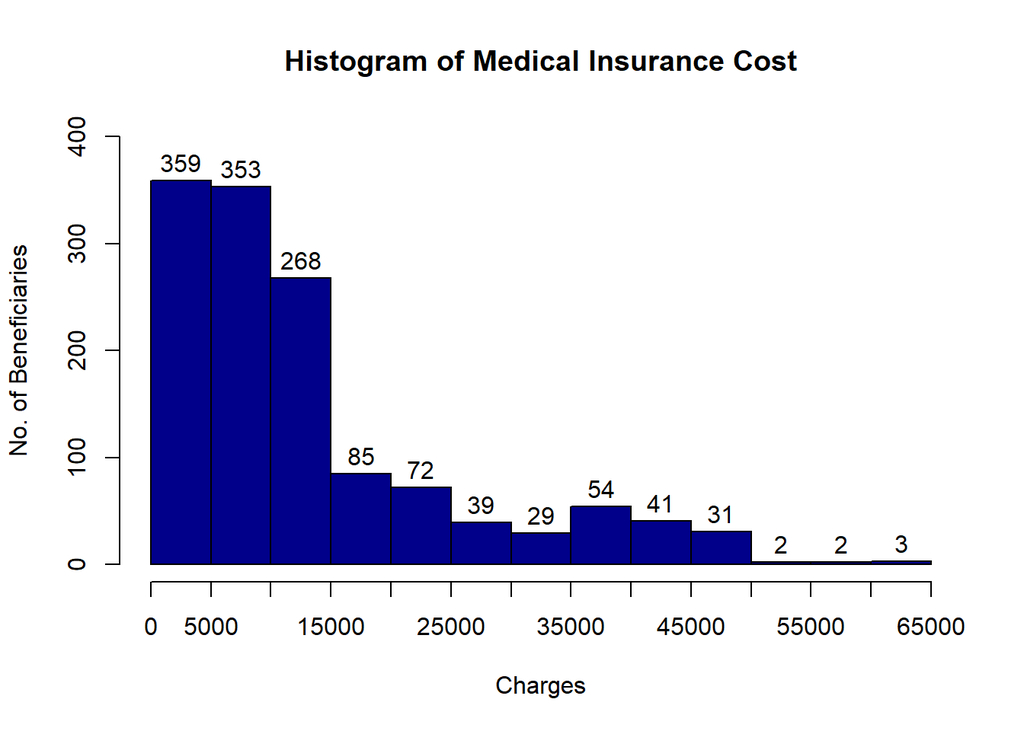

```r
h.charges <- hist(df$charges,
            main = "Histogram of Medical Insurance Cost",
            labels = TRUE,
            xlab = "Charges",
            ylab = "No. of Beneficiaries",
            col = "darkblue",
            xlim = c(0, 65000),
            ylim = c(0, 400),
            xaxp = c(0, 65000, 13))
```

```r
charges.group <- cut(df$charges, breaks = h.charges$breaks, include.lowest = TRUE, dig.lab = 5)
charges_freq <- table(charges.group)
kable(charges_freq, caption = "Frequency Distribution by Medical Insurance Cost")
```

Frequency Distribution by Medical Insurance Cost

| charges.group | Freq |
| --- | --- |
| [0,5000] | 359 |
| (5000,10000] | 353 |
| (10000,15000] | 268 |
| (15000,20000] | 85 |
| (20000,25000] | 72 |
| (25000,30000] | 39 |
| (30000,35000] | 29 |
| (35000,40000] | 54 |
| (40000,45000] | 41 |
| (45000,50000] | 31 |
| (50000,55000] | 2 |
| (55000,60000] | 2 |
| (60000,65000] | 3 |

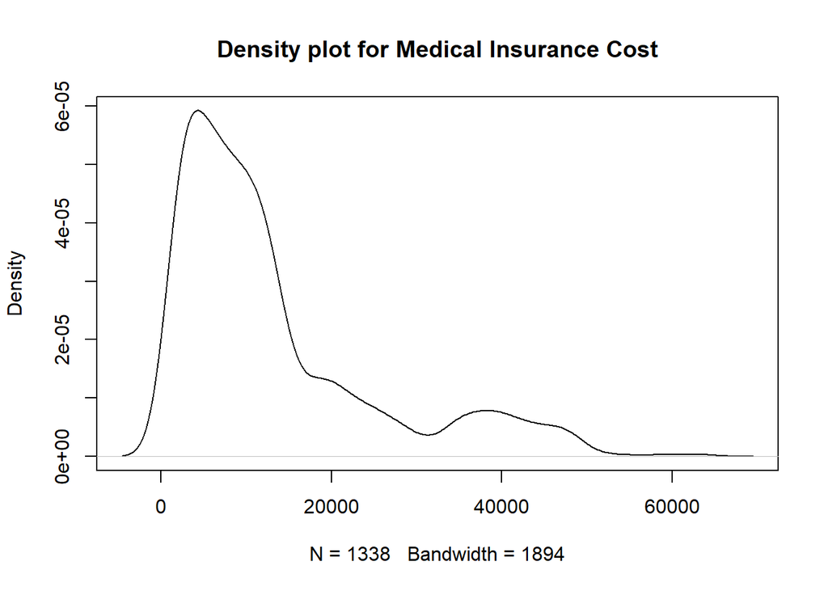

```r
plot(density(df$charges), main="Density plot for Medical Insurance Cost")
```

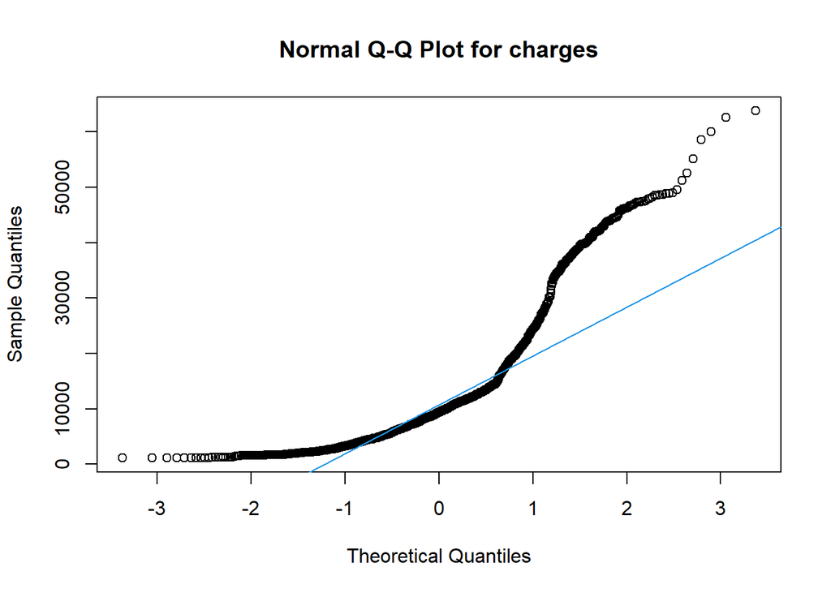

```r
qqnorm(df$charges,
       main="Normal Q-Q Plot for charges")
qqline(df$charges, col=4)
```

```r
shapiro.test(df$charges)
```

```
##
##  Shapiro-Wilk normality test
##
## data:  df$charges
## W = 0.81469, p-value < 2.2e-16
```

```r
# H0: Data was drawn from a normally distributed population
# W = 0.81469, is quite far from 1
# Given p < 2.2e-16 < 0.05, there is sufficient evidence to reject H0.
# Hence, we can conclude data is not normally distributed.
```

From the histogram, the distribution of charges is right skewed. From the Shapiro-Wilk test, given p-value < 2.2e-16 < 0.05 and W = 0.81469 which is quite far from 1, we have sufficient evidence to reject H0 that the data is normally distributed and conclude that charges is not normally distributed.

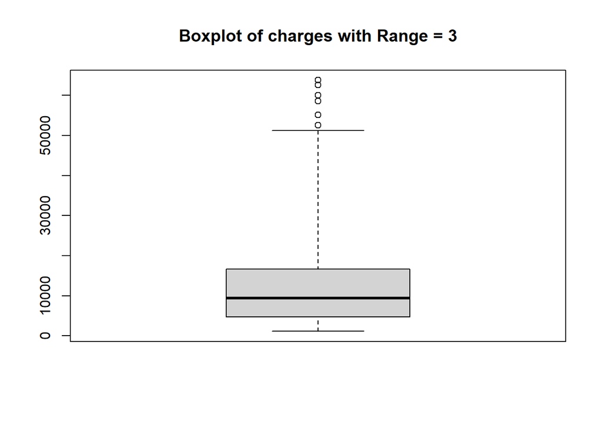

```r
bcharges3 <- boxplot(df$charges,
              range = 3,
              main = "Boxplot of charges with Range = 3")
```

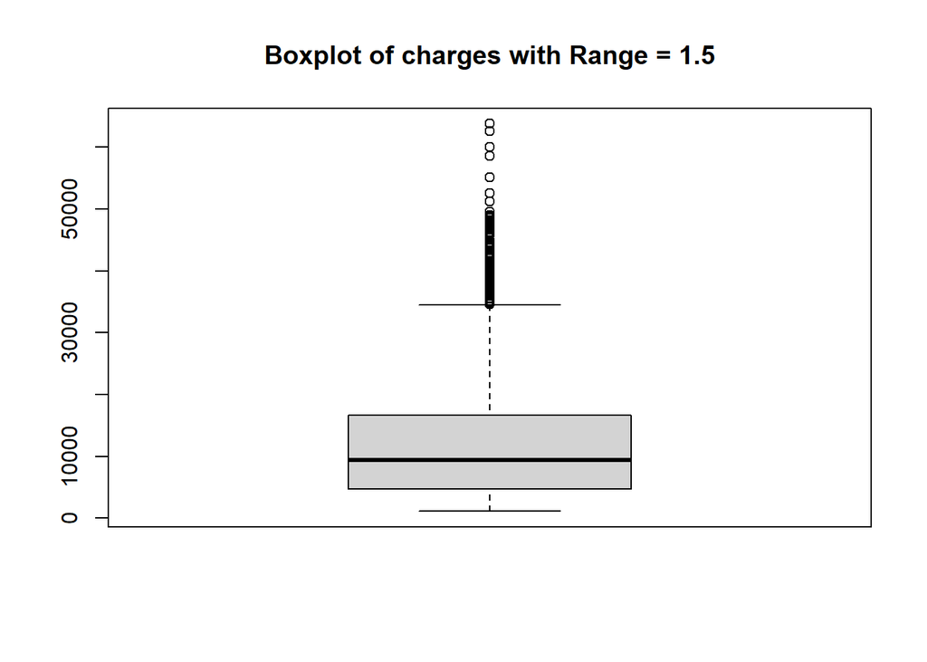

```r
bcharges1.5 <- boxplot(df$charges,
                 range = 1.5,
                 main="Boxplot of charges with Range = 1.5")
```

```r
# extreme outliers are those in bX3$out
bcharges3$out
```

```
## [1] 63770.43 58571.07 55135.40 52590.83 60021.40 62592.87
```

```r
length(bcharges3$out)
```

```
## [1] 6
```

```r
min(bcharges3$out)
```

```
## [1] 52590.83
```

```r
max(bcharges3$out)
```

```
## [1] 63770.43
```

```r
length(bcharges1.5$out)
```

```
## [1] 139
```

```r
min(bcharges1.5$out)
```

```
## [1] 34617.84
```

```r
# moderate outliers are those in bX1.5$out but not in bX3$out
# We can use setdiff() to find the difference in two vectors

charges_out.mild <- setdiff(bcharges1.5$out, bcharges3$out)
max(charges_out.mild)
```

```
## [1] 51194.56
```